# Practical 7 Supervised learning: Nonlinear Regression Introduction

# Q6

**Create a model called `pw2_mod` with one predictor: `I(lstat <= median(lstat))`. Create a pred_plot with this model. Use the coefficients in `coef(pw2_mod)` to find out what the predicted value for a low-lstat neighbourhood is.**

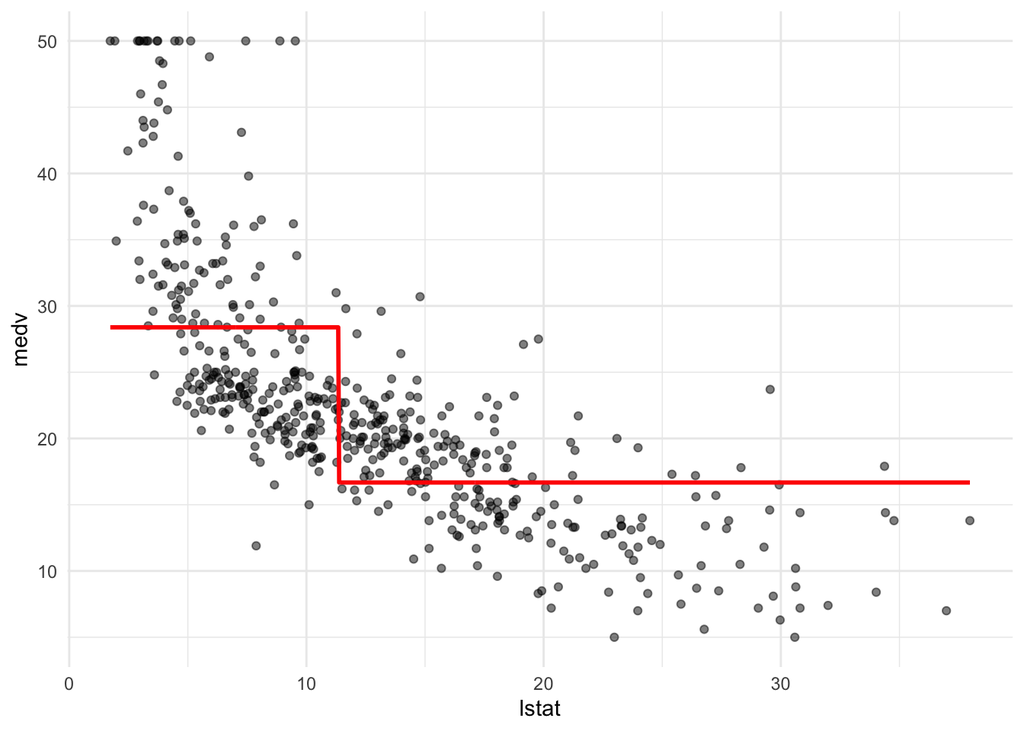

```r
pw2_mod <- lm(medv ~ I(lstat <= median(lstat)), data = Boston)

pred_plot(pw2_mod)
```

```r
coef(pw2_mod)
```

```
##                   (Intercept) I(lstat <= median(lstat))TRUE
##                      16.67747                      11.71067
```

```r
# 16.67747 + 11.71067
```

# Q7

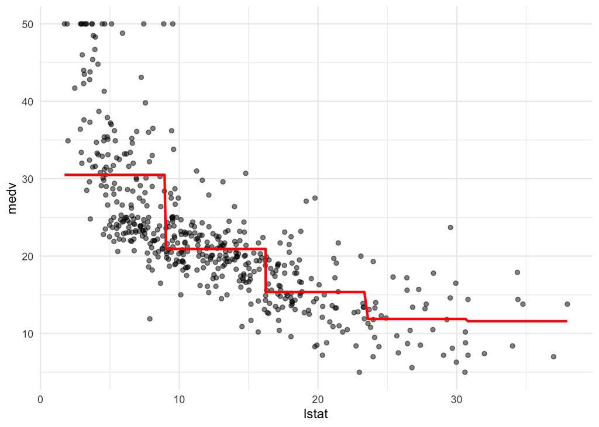

```r
pw5_mod <- lm(medv ~ cut(lstat, 5), data = Boston)

pred_plot(pw5_mod)
```

# Q8

**Optional: Create a piecewise regression model `pwq_mod` where the sections are not equally spaced, but have equal amounts of training data. Hint: use the `quantile()` function.**